# Homework 1 - Bayesian Statistics 2023

Vincenzo Zimbardo

12/05/2023

# Exercise 1

A Linear Congruential Generator (LCG) is given by
$$\begin{align*}
x_i & = a_0 + a_1 x_{i-1} \mod M \\
u_i & = x_i / M
\end{align*}$$
and when $a_0=0$ yields the Multiplicative Congruential Generator (MCG). Marsaglia showed that the consecutive tuples $(u_i, \ldots, u_{i+k-1})$ from an MCG have a lattice structure.

Consider two MCG, with multipliers $a_1=33$ and $a_2=44$ respectively, both with modulo $M=59$.

```r
# Multiplicative Congruential Generator
MCG <- function(n, a, M) {
  seed <- 1
  r <- rep(0, n+1)
  r[1] <- seed
  for (i in 2:(n+1)) {
    r[i] <- (a*r[i-1])%%M
  }
  r <- r[-1]/M
  return(r)
}
```

```r
# Variables
n <- 59
a1 <- 33
a2 <- 44
M <- 59
```

### Plot the lattice structure for $k=2$.

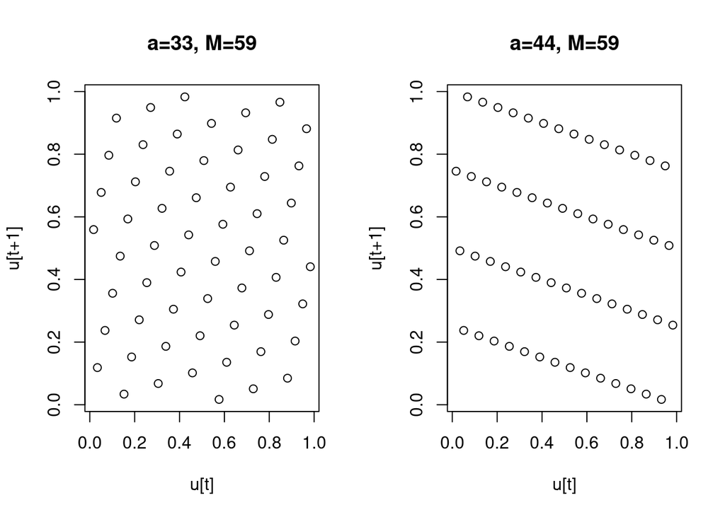

```r
# Plot lattices
par(mfcol=c(1,2))
u1 <- MCG(n, a1, M)
plot(u1[-n], u1[-1], xlab="u[t]", ylab="u[t+1]", main="a=33, M=59")
u2 <- MCG(n, a2, M)
plot(u2[-n], u2[-1], xlab="u[t]", ylab="u[t+1]", main="a=44, M=59")
```

### Find a lattice basis

```r
library(geometry)

FindBasis <- function(u) {
  # Define vectors (their dim is n-1)
  x <- u[-n]
  y <- u[-1]
  # Choose one point as the origin (the last one), say (x0,y0)
  x0 <- x[n-1]
  y0 <- y[n-1]
  # Find the closest point to (x0,y0), say (x1,y1)
  dist2 <- (x - x0)^2 + (y - y0)^2
  dist2 <- dist2[-(n-1)]
  minidx <- which.min(dist2)
  x1 <- x[minidx]
  y1 <- y[minidx]
  # Find the second closest point to (x0,y0), say (x2,y2), s.t. the corresponding vector
  # is also linearly independent from the first
  bol <- TRUE
  dist_orig <- dist2
  while (bol) {
    dist2 <- dist2[-minidx]
    minidx <- which.min(dist2)
    minidx_orig <- which(dist_orig == dist2[minidx])
    det <- (x1-x0)*(y[minidx_orig]-y0)-(x[minidx_orig]-x0)*(y1-y0)
    if (abs(det) > 1e-6) {
       bol <- FALSE
    }
  }
  x2 <- x[minidx_orig]
  y2 <- y[minidx_orig]
  # Now plot the basis
  plot(x, y, asp=1)
  points(x0, y0, col="blue", lwd=5)
  points(x1, y1, col="red", lwd=5)
  points(x2, y2, col="green", lwd=5)
  arrows(x0,y0,x1,y1, code=2, lwd=2, length=.15)
  arrows(x0,y0,x2,y2, code=2, lwd=2, length=.15)

  return (list(x0,y0,x1,y1,x2,y2,x,y))
}
```

Plot the basis, say $\vec{v_1}$ and $\vec{v_2}$

```r
pnts1 <- FindBasis(u1)
```

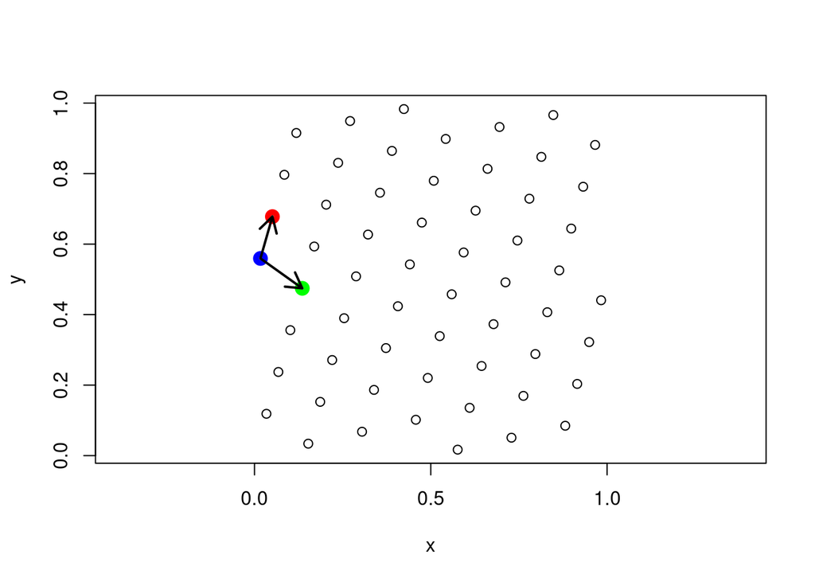

```r
pnts2 <- FindBasis(u2)
```

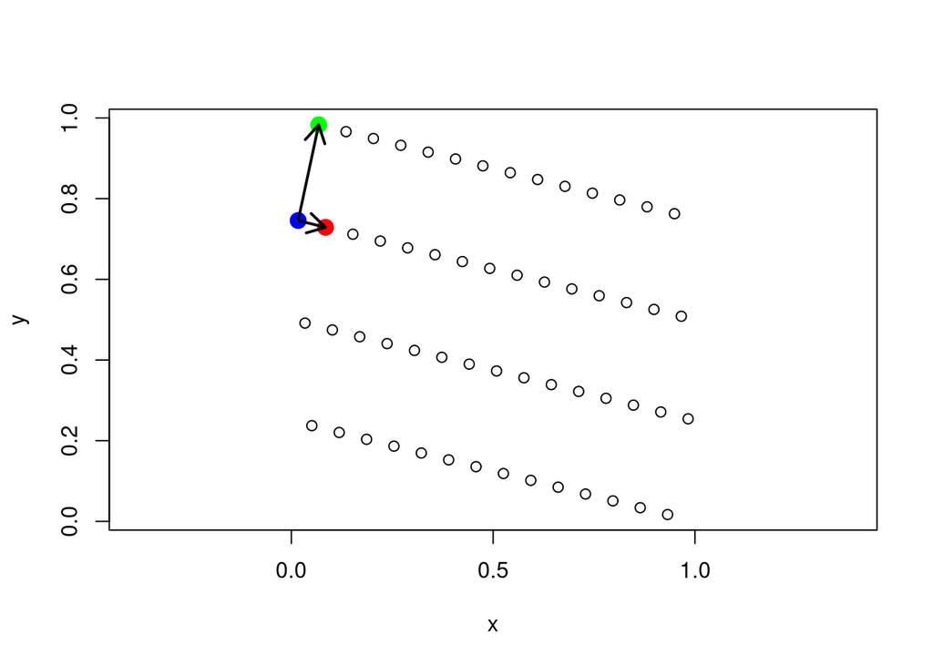

### Find the distance among the parallel lines.

For $i=1,2$, let $\vec{d_i}$ the component of the vector $\vec{v_i}$ orthogonal to the other basis vector. The distances between the two sets of parallel lines will be the norm of these vectors.

$$\begin{align*}
\vec{d}_1 &= \vec{v}_1 - \left(\frac{\vec{v}_1 \cdot
\vec{v}_2}{\vec{v}_2 \cdot \vec{v}_2}\right) \vec{v}_2 &
\vec{d}_2 &= \vec{v}_2 - \left(\frac{\vec{v}_1 \cdot
\vec{v}_2}{\vec{v}_1 \cdot \vec{v}_1}\right) \vec{v}_1
\end{align*}$$

```r
distance <- function(pnts) {
  # Extract vector coordinates
  x0 <- pnts[[1]]
  y0 <- pnts[[2]]
  v1x <- pnts[[3]]-x0
  v1y <- pnts[[4]]-y0
  v2x <- pnts[[5]]-x0
  v2y <- pnts[[6]]-y0
  # Calculate the two coefficients in the linear combination
  scal <- v1x*v2x + v1y*v2y
  scal1 <- scal / ( v2x*v2x + v2y*v2y )
  scal2 <- scal / ( v1x*v1x + v1y*v1y )
  # Generate the coordinates of the d vectors
  d1x <- v1x - scal1*v2x
  d1y <- v1y - scal1*v2y
  d2x <- v2x - scal2*v1x
  d2y <- v2y - scal2*v1y
  # Replot lattices with also the d vectors
  x <- unlist(pnts[7])
  y <- unlist(pnts[8])

  plot(x, y, asp=1)

  points(x0, y0, col="blue", lwd=8)
  points(pnts[[3]], pnts[[4]], col="red", lwd=5)
  points(pnts[[5]], pnts[[6]], col="green", lwd=5)

  arrows(x0,y0,x0+v1x,y0+v1y, code=2, lwd=2,length=.15)
  arrows(x0,y0,x0+v2x,y0+v2y, code=2, lwd=2, length=.15)

  arrows(x0,y0,x0+d1x,y0+d1y, col="yellow", code=2, lwd=2, lty=2, length=.15)
  arrows(x0,y0,x0+d2x,y0+d2y, col="lightblue", code=2, lwd=2, lty=2, length=.15)

  # Calculate the distances and return
  dist1 <- sqrt(d1x^2 + d1y^2)
  dist2 <- sqrt(d2x^2 + d2y^2)

  return (max(c(dist1,dist2)))

}
```

Replot the lattices including the $\vec{d}$ vectors:

```r
  # First MCG
  d1 <- distance(pnts1)
```

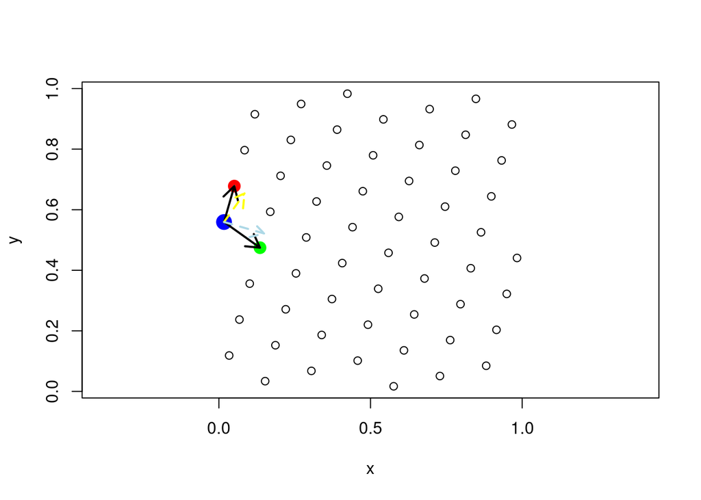

```r
  # Second MCG
  d2 <- distance(pnts2)
```

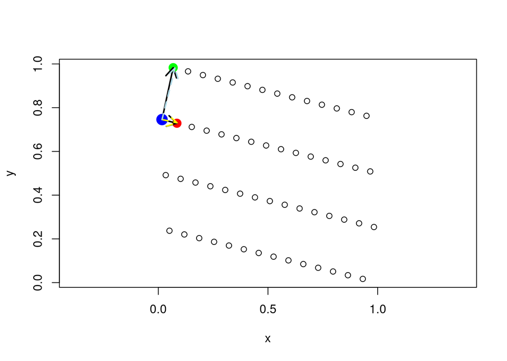

The maximum distance between parallel lines is dist1 = 0.137361 for the first MCG, while it is dist2 = 0.242536 for the second. This distance is a measure of the quality of the $MCG$, the smaller it is, the better the $MCG$ is.

### Find another value of $a$ for which the period equals $P=58$, but the maximum distance between parallel lines is greater than in the case $a=44$